# Quizz Session 3

## Mediation models

**1. In order to estimate all the effects included in a model like the shown below we require**

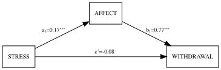

only a multiple linear regression model. two simple and a multiple linear regression models. two simple linear regression models. three simple linear regression models.

**2. Given the results for the mediation model shown below we can conclude that there's a significant total effect of the economic stress condition on the entrepreneurial decision**

```
************ TOTAL, DIRECT, AND INDIRECT EFFECTS OF X ON Y ************

Total effect of X on Y:
     effect        se         t         p      LLCI      ULCI
     0.0561    0.0542    1.0353    0.3015   -0.0506    0.1629

Direct effect of X on Y:
     effect        se         t         p      LLCI      ULCI
    -0.0768    0.0524   -1.4667    0.1437   -0.1800    0.0263

Indirect effect(s) of X on Y:
          Effect    BootSE  BootLLCI  BootULCI
affect    0.1330    0.0334    0.0713    0.2026
```

**3. Given the previous summary we can conclude that**

by increasing one unit the affect the withdrawal decision will increase 0.13 units. by increasing one unit the affect the withdrawal decision will decrease 0.08 units. by increasing one unit the stress the withdrawal decision will decrease 0.08 units, via the affect level. by increasing one unit the stress the withdrawal decision will increase 0.13 units, via the affect level.

**4. When running the Bootstrap procedure (see summary above), we can conclude that there's a significant indirect effect since the 0 value is not captured within its boundaries.**

**5. The total effect of condition on reaction is equal to $a_1\times b_1 + a_2\times b_2$.**

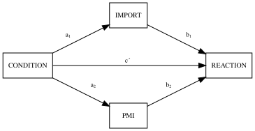

**6. The total indirect effect implies the causal mechanisms by which condition influences the final reaction, that is, the mediated effect of perceived importance and presumed media influence.**

**7. Once estimated the multiple mediation model by means of process macro we can conclude**

```
************ TOTAL, DIRECT, AND INDIRECT EFFECTS OF X ON Y ************

Total effect of X on Y:
     effect        se         t         p      LLCI      ULCI
     0.4957    0.2775    1.7860    0.0766   -0.0538    1.0452

Direct effect of X on Y:
     effect        se         t         p      LLCI      ULCI
     0.1034    0.2391    0.4324    0.6662   -0.3701    0.5768

Indirect effect(s) of X on Y:
          Effect    BootSE  BootLLCI  BootULCI
TOTAL     0.3923    0.1659    0.0939    0.7407
pmi       0.1890    0.1044    0.0099    0.4214
import    0.2033    0.1152    0.0040    0.4636
```

there's a full mediation on the casual relationship between condition and reaction. none of the indirect effects yields significant results. there's a partial mediation on the casual relationship between condition and reaction. the reaction is not influenced by the experimental condition.

## Moderation models

**8. The estimates provided by the process macro (model 1) and that provided by lm function are equal. `**

```
Call:
lm(formula = justify ~ frame * skeptic, data = disasterDF)

Residuals:
    Min      1Q  Median      3Q     Max
-2.1267 -0.5864 -0.0117  0.5084  2.5484

Coefficients:
              Estimate Std. Error t value Pr(>|t|)
(Intercept)    2.45153    0.14904  16.449  < 2e-16 ***
frame         -0.56247    0.21792  -2.581 0.010539 *
skeptic        0.10508    0.03813   2.756 0.006375 **
frame:skeptic  0.20118    0.05527   3.640 0.000344 ***
---
Signif. codes:  0 '***' 0.001 '**' 0.01 '*' 0.05 '.' 0.1 ' ' 1

Residual standard error: 0.8129 on 207 degrees of freedom
Multiple R-squared:  0.2463,    Adjusted R-squared:  0.2353
F-statistic: 22.54 on 3 and 207 DF,  p-value: 1.138e-12
```

**9. The region defined by the mean of skepticism $\pm$ 1·SD always delimits a region of significance in the case of existing a moderated effect of frame on justification score. `**

**10. The moderated effect of skepticism on justification score is more credible for high levels of skepticism than that estimated for low levels of this variable. `**

```
JOHNSON-NEYMAN INTERVAL

When skeptic is OUTSIDE the interval [1.17, 3.93], the slope of frame is p
< .05.

Note: The range of observed values of skeptic is [1.00, 9.00]
```

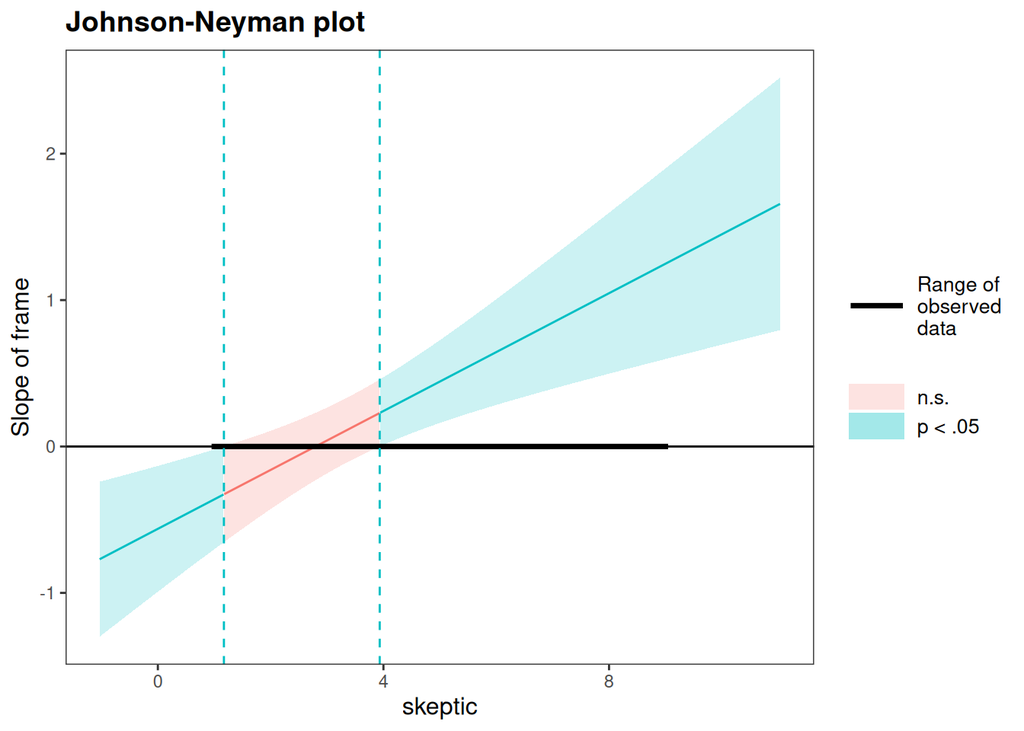